# Reproduction of results for CD

Facundo Muñoz

2016-08-18

Firstly, we reproduce the methodology of (Pliūra et al. 2011) in order to have a reference for comparison. We derive conclusions from the model fit, although we show that the model does not pass the most basic diagnostics.

Our second model substitutes the genetic effect at a **family** level by an additive effect at **individual** level. We show that this model improves significantly the fit, and allows to estimate the heritability more accurately.

Finaly, we fit a third model with a **spatio-temporal** effect in replacement of the blocks effects and their interactions.

# 1 Exploratory plots

This plot uses the variable CD in its original scale.

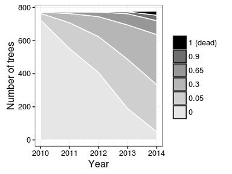

Crown dieback (CD) progress over time

# 2 Reproducing the methodology of (Pliūra et al. 2011)

For the analysis of data from one trial, they use a fixed block effect $b_j$, a **random** family effect $s_l$ and a fixed population effect $p_m$. Furthermore, they include the interactions between the population and the family with the block.

As they did not have several measurements in different points in time, we will also include a fixed *Year* effect, to account for global differences from year to year.

```
Linear mixed model fit by REML ['lmerMod']
Formula: value ~ Year + PROV + BLC + PROVxBLC + (1 | FAM) + (1 | FAMxBLC)
   Data: ml$dat

REML criterion at convergence: 5940.2

Scaled residuals:
    Min      1Q  Median      3Q     Max
-4.3837 -0.5658  0.1227  0.6818  2.9347

Random effects:
 Groups   Name        Variance Std.Dev.
 FAMxBLC  (Intercept) 0.02397  0.1548
 FAM      (Intercept) 0.04917  0.2217
 Residual             0.25066  0.5007
Number of obs: 3861, groups:  FAMxBLC, 175; FAM, 23

Fixed effects:
             Estimate Std. Error t value
(Intercept)   2.63735    0.11321   23.30
Year.L       -0.91455    0.01801  -50.77
Year.Q       -0.11103    0.01802   -6.16
Year.C        0.01287    0.01802    0.71
Year^4        0.03454    0.01802    1.92
PROVc         0.16168    0.21926    0.74
PROVv        -0.13041    0.17103   -0.76
BLC2          0.12472    0.13321    0.94
BLC3         -0.17973    0.14871   -1.21
BLC4         -0.27026    0.13219   -2.04
BLC5         -0.13639    0.15440   -0.88
BLC6          0.04237    0.13869    0.31
BLC7         -0.15144    0.13921   -1.09
BLC8         -0.04183    0.13661   -0.31
BLC9          0.14144    0.13404    1.06
BLC10         0.05546    0.13921    0.40
BLC11        -0.13768    0.15065   -0.91
PROVxBLCa:2  -0.15254    0.18250   -0.84
PROVxBLCa:3   0.25118    0.18515    1.36
PROVxBLCa:4   0.05871    0.17833    0.33
PROVxBLCa:5   0.08538    0.19333    0.44
PROVxBLCa:6   0.13568    0.17853    0.76
PROVxBLCa:7   0.15497    0.18174    0.85
PROVxBLCa:8  -0.11446    0.17944   -0.64
PROVxBLCa:9  -0.32073    0.18375   -1.75
PROVxBLCa:10 -0.26543    0.18184   -1.46
PROVxBLCa:11  0.01970    0.18500    0.11
PROVxBLCc:1   0.01717    0.18527    0.09
PROVxBLCc:2  -0.22708    0.17779   -1.28
PROVxBLCc:3   0.23067    0.19212    1.20
PROVxBLCc:4  -0.05996    0.18095   -0.33
PROVxBLCc:5   0.01753    0.19121    0.09
PROVxBLCc:6  -0.08019    0.18597   -0.43
PROVxBLCc:7  -0.06921    0.18223   -0.38
PROVxBLCc:8  -0.10372    0.18060   -0.57
PROVxBLCc:9  -0.21890    0.17783   -1.23
PROVxBLCc:10 -0.12006    0.18462   -0.65
fit warnings:
fixed-effect model matrix is rank deficient so dropping 12 columns / coefficients
```

Note that the estimates of variance components are quite small in comparison with the Residual variance (an order of magnitude smaller). However, they are both significant, according to the Confidence Intervals on the Standard Deviations, as shown below.

These CIs are computed by likelihood profiling. This is why the REML point estimate of the first SD is near the right extreme of the CI. The ML point estimate is much more centered in the CI.

By the way, do not confound the `Std.Dev.` with the Standard Error of the estimates. Standard Errors (and p-values of Z tests) are not shown because most of the times (e.g. unbalanced or partially crossed designs) are inadequate.

```
           2.5 %    97.5 %
.sig01 0.1046827 0.1564060
.sig02 0.1501650 0.2940928
.sigma 0.4892206 0.5120759
```

## 2.1 Model diagnostics

Check residuals

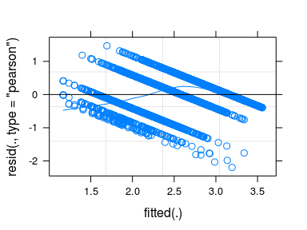

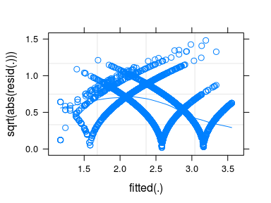

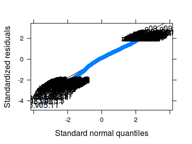

```
    Shapiro-Wilk normality test

data:  resid(ml$ref$res1)
W = 0.98236, p-value < 2.2e-16
```

As a consequence of the discrete response, these residuals are obviously **not** independent and normally distributed, in contrast to the results of (Pliūra et al. 2011) (not reported) who claimed that the residuals showed no problems.

Therefore, the following results are to be taken with skepticism.

## 2.2 Heritability

Note that this method can give estimates above 1, as a consequence of estimating the additive-genetic variance as $4\sigma^2_f$.

These results give an heritability estimate of **0.61** with a 95% bootstrap Confidence Interval of **0.25, 0.97**.

Here we computed the heritability considering the interaction between Family and Block as part of the Phenotypic variance, since this is recommended practice for a GxE component like this one (Visscher, Hill, and Wray 2008).

However, this was not the approach of (Pliūra et al. 2011). They **excluded** the variance of the interaction in the denominator. In fact, they also excluded the environmental variability of the blocks by modeling them as fixed effects.

Regardless of whether this approach is correct or not, its consequence is an increase on the heritability, whose point estimate becomes 0.66

However, it must be noted the **huge sampling variability of this estimation procedure**!!!

## 2.3 Other effects

According to the (profile) confidence intervals, we don’t observe a significant effect of the population.

```
           2.5 %    97.5 %
PROVc -0.2261944 0.5522106
PROVv -0.4386266 0.1791152
```

```
               2.5 %      97.5 %
Year.L -0.9498450025 -0.87924265
Year.Q -0.1463245283 -0.07571717
Year.C -0.0224336873  0.04818181
Year^4 -0.0007713788  0.06984788
```

We have confidence intervals for the parameters. Let’s compute bootstrap-based CIs for the specific effect of each year.

The following figure shows the effect of the years, with 95% confidence intervals estimated by bootstrapping.

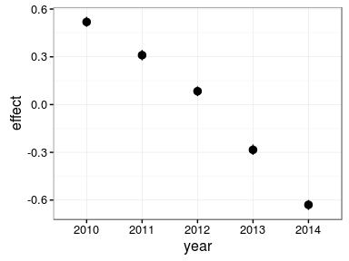

If we removed the **Provenance** effect (and its interaction), we loose some goodnes of fit, but the difference is not significant.

```
Linear mixed model fit by REML ['lmerMod']
Formula: value ~ Year + BLC + (1 | FAM) + (1 | FAMxBLC)
   Data: ml$dat

REML criterion at convergence: 5917.5

Scaled residuals:
    Min      1Q  Median      3Q     Max
-4.4041 -0.5780  0.1272  0.6871  2.9763

Random effects:
 Groups   Name        Variance Std.Dev.
 FAMxBLC  (Intercept) 0.02509  0.1584
 FAM      (Intercept) 0.05106  0.2260
 Residual             0.25068  0.5007
Number of obs: 3861, groups:  FAMxBLC, 175; FAM, 23

Fixed effects:
             Estimate Std. Error t value
(Intercept)  2.662153   0.068974   38.60
Year.L      -0.914515   0.018016  -50.76
Year.Q      -0.110996   0.018017   -6.16
Year.C       0.012888   0.018019    0.72
Year^4       0.034544   0.018020    1.92
BLC2        -0.020399   0.069816   -0.29
BLC3         0.008535   0.070327    0.12
BLC4        -0.292146   0.069977   -4.17
BLC5        -0.104419   0.070846   -1.47
BLC6         0.052474   0.069452    0.76
BLC7        -0.142349   0.069443   -2.05
BLC8        -0.131628   0.069876   -1.88
BLC9        -0.044395   0.069895   -0.64
BLC10       -0.088708   0.070455   -1.26
BLC11       -0.138115   0.068743   -2.01
```

```
                    2.5 %       97.5 %
.sig01                 NA           NA
.sig02                 NA           NA
.sigma                 NA           NA
(Intercept)  2.5269670060  2.797339699
Year.L      -0.9498247361 -0.879205213
Year.Q      -0.1463087263 -0.075684201
Year.C      -0.0224278385  0.048204815
Year^4      -0.0007745013  0.069861904
BLC2        -0.1572357444  0.116438177
BLC3        -0.1293021682  0.146372759
BLC4        -0.4292981659 -0.154994403
BLC5        -0.2432744471  0.034435620
BLC6        -0.0836482922  0.188596689
BLC7        -0.2784553229 -0.006242770
BLC8        -0.2685827153  0.005327622
BLC9        -0.1813853861  0.092596336
BLC10       -0.2267973830  0.049381703
BLC11       -0.2728495414 -0.003380929
```

```
Data: ml$dat
Models:
ml$ref$res2: value ~ Year + BLC + (1 | FAM) + (1 | FAMxBLC)
ml$ref$res1: value ~ Year + PROV + BLC + PROVxBLC + (1 | FAM) + (1 | FAMxBLC)
            Df    AIC    BIC  logLik deviance  Chisq Chi Df Pr(>Chisq)
ml$ref$res2 18 5884.9 5997.5 -2924.4   5848.9
ml$ref$res1 40 5897.7 6148.0 -2908.8   5817.7 31.176     22    0.09256 .
---
Signif. codes:  0 '***' 0.001 '**' 0.01 '*' 0.05 '.' 0.1 ' ' 1
```

However, since the **families are nested within provenances**, we should take into account the provenances when comparing families. So we use this latter model to produce the following Figure, which shows the predicted family effects with their corresponding prediction intervals, with the model without explicit provenances. We see that families `c09` and `a10` are clearly more affected by the disease, while families `a03`, `a09`and `c01` seem to be the most **resistant** ones.

```
$FAM
```

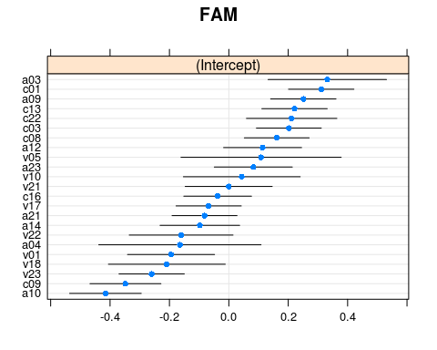

## 2.4 The method from (Pliūra et al. 2011) in a Bayesian setting

We now develop an analog model in a Bayesian framework, in order to compare the improvement in marginal likelihood and DIC with more complex models. Note that the variance estimates (inverse of precisions) are similar, and the family point estimates are also aligned. The slight shift absorbed in some other effect.

```
Call:
c("inla(formula = value ~ Year + BLC + f(FAM, model = \"iid\") + f(FAMxBLC, ",  "    model = \"iid\"), data = ml$dat, control.compute = list(dic = TRUE, ",  "    waic = TRUE, cpo = TRUE, po = TRUE, config = TRUE), control.predictor = list(compute = TRUE), ",  "    control.fixed = list(expand.factor.strategy = \"inla\"))" )

Time used:
 Pre-processing    Running inla Post-processing           Total
         0.5610          8.1695          0.5942          9.3247

Fixed effects:
               mean      sd 0.025quant 0.5quant 0.975quant    mode kld
(Intercept)  2.6033 17.0561   -30.8836   2.6028    36.0623  2.6033   0
Year2010     0.5188 14.1421   -27.2470   0.5184    28.2615  0.5188   0
Year2011     0.3113 14.1421   -27.4545   0.3109    28.0539  0.3113   0
Year2012     0.0838 14.1421   -27.6820   0.0834    27.8265  0.0838   0
Year2013    -0.2846 14.1421   -28.0504  -0.2850    27.4580 -0.2846   0
Year2014    -0.6294 14.1421   -28.3952  -0.6298    27.1132 -0.6294   0
BLC1         0.0800  9.5347   -18.6399   0.0797    18.7843  0.0800   0
BLC2         0.0594  9.5347   -18.6606   0.0591    18.7637  0.0594   0
BLC3         0.0893  9.5348   -18.6307   0.0890    18.7936  0.0893   0
BLC4        -0.2121  9.5348   -18.9320  -0.2124    18.4922 -0.2121   0
BLC5        -0.0246  9.5348   -18.7446  -0.0249    18.6797 -0.0246   0
BLC6         0.1329  9.5347   -18.5870   0.1327    18.8373  0.1329   0
BLC7        -0.0624  9.5347   -18.7824  -0.0627    18.6419 -0.0624   0
BLC8        -0.0528  9.5347   -18.7727  -0.0531    18.6515 -0.0528   0
BLC9         0.0353  9.5347   -18.6846   0.0351    18.7396  0.0353   0
BLC10       -0.0090  9.5348   -18.7289  -0.0092    18.6954 -0.0090   0
BLC11       -0.0359  9.5347   -18.7558  -0.0362    18.6683 -0.0359   0

Random effects:
Name      Model
 FAM   IID model
FAMxBLC   IID model

Model hyperparameters:
                                          mean     sd 0.025quant 0.5quant
Precision for the Gaussian observations  4.003 0.0932       3.82    4.003
Precision for FAM                       22.440 7.5615      10.83   21.402
Precision for FAMxBLC                   41.642 7.7252      28.86   40.805
                                        0.975quant   mode
Precision for the Gaussian observations      4.186  4.004
Precision for FAM                           40.172 19.449
Precision for FAMxBLC                       59.099 39.094

Expected number of effective parameters(std dev): 130.07(5.816)
Number of equivalent replicates : 29.84

Deviance Information Criterion (DIC) ...: 5767.98
Effective number of parameters .........: 131.96

Watanabe-Akaike information criterion (WAIC) ...: 5766.39
Effective number of parameters .................: 125.97

Marginal log-Likelihood:  -3056.41
CPO and PIT are computed

Posterior marginals for linear predictor and fitted values computed
```

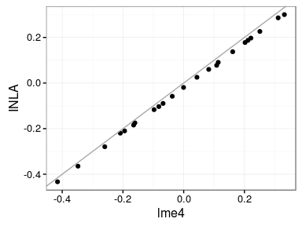

Posterior heritability:

```
   2.5%   97.5%
0.32875 1.00000
```

# 3 Substituting the Family effect by an additive-genetic effect at individual level

We also removed the `Family-Block` interaction, because it gets absorbed completely by the individual effect.

```
Call:
c("inla(formula = ml$add$fml, data = ml$add$dat, control.compute = list(dic = TRUE, ",  "    waic = TRUE, cpo = TRUE, po = TRUE, config = TRUE), control.predictor = list(compute = TRUE), ",  "    control.family = list(hyper = list(prec = prec.A)), control.fixed = list(expand.factor.strategy = \"inla\"))" )

Time used:
 Pre-processing    Running inla Post-processing           Total
         0.4355         17.9434          1.0378         19.4167

Fixed effects:
           mean     sd 0.025quant 0.5quant 0.975quant   mode kld
Year2010 2.3016 7.9057   -13.2200   2.3014    17.8102 2.3016   0
Year2011 2.0941 7.9057   -13.4275   2.0939    17.6027 2.0941   0
Year2012 1.8666 7.9057   -13.6550   1.8664    17.3752 1.8666   0
Year2013 1.4982 7.9057   -14.0234   1.4979    17.0068 1.4982   0
Year2014 1.1537 7.9057   -14.3679   1.1534    16.6623 1.1537   0
BLC1     0.8936 7.9058   -14.6282   0.8934    16.4025 0.8936   0
BLC2     0.8743 7.9058   -14.6475   0.8741    16.3832 0.8743   0
BLC3     0.9050 7.9058   -14.6168   0.9048    16.4139 0.9050   0
BLC4     0.6043 7.9058   -14.9176   0.6040    16.1131 0.6043   0
BLC5     0.7885 7.9058   -14.7334   0.7882    16.2973 0.7885   0
BLC6     0.9475 7.9058   -14.5743   0.9473    16.4564 0.9475   0
BLC7     0.7478 7.9058   -14.7740   0.7476    16.2567 0.7478   0
BLC8     0.7596 7.9058   -14.7622   0.7594    16.2685 0.7596   0
BLC9     0.8483 7.9058   -14.6735   0.8481    16.3571 0.8483   0
BLC10    0.8059 7.9058   -14.7159   0.8057    16.3148 0.8059   0
BLC11    0.7394 7.9058   -14.7823   0.7392    16.2481 0.7394   0

Random effects:
Name      Model
 recode   Generic0 model

Model hyperparameters:
                                         mean     sd 0.025quant 0.5quant
Precision for the Gaussian observations 6.200 0.1572      5.896    6.199
Precision for recode                    6.543 0.4251      5.747    6.529
                                        0.975quant  mode
Precision for the Gaussian observations      6.514 6.196
Precision for recode                         7.417 6.503

Expected number of effective parameters(std dev): 617.10(9.05)
Number of equivalent replicates : 6.289

Deviance Information Criterion (DIC) ...: 4547.76
Effective number of parameters .........: 618.66

Watanabe-Akaike information criterion (WAIC) ...: 4573.31
Effective number of parameters .................: 568.23

Marginal log-Likelihood:  -2794.26
CPO and PIT are computed

Posterior marginals for linear predictor and fitted values computed
```

There is a hughe improvement both in DIC and in marginal likelihood. Which is natural, as this model fits individuals, rather than families, and therefore explains part of what was residual variability before. The appeal of this approach is that it gives a direct estimate of the additive-genetic variance, from where we can derive the heritability. Moreover, by using the Bayesian approach, we get a posterior density distribution, which is directly interpretable.

## 3.1 Heritability

In order to compute the posterior density of the heritability, we sample from the posterior distributions of the hyperparameters of the model, and build a posterior sample of heritabilities with the formula
$$h^2 = \frac{\sigma^2_a}{\sigma^2_a + \sigma^2}$$

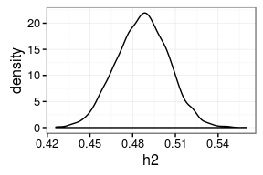

Posterior heritability

These results give a heritability esimate of about 0.49 with a 95% **Credible Interval** of 0.45 – 0.52

# 4 Spatio-temporal model with family and additive genetic effects

The following model substitutes the Blocks effects by a continuously varying non-separable spatiotemporal effect $\Theta_{ij}$ that accounts for the pattern of spread of the disease in time.

$$\begin{aligned}
y_{ijk} = & Year_i + \Theta_{ij} + a_k + \varepsilon_{ijk}\\
\boldsymbol\Theta \sim & N\big(\boldsymbol0, \tau_\Theta^2 \mathbf{Q}(\rho)\big) \\
\boldsymbol{a} \sim & N\big(\boldsymbol0, \tau_a^2 \mathbf{A}^{-1}\big) \\
\boldsymbol\varepsilon \sim & N\big(\boldsymbol0, \mathbf{I}\big),
\end{aligned}$$

We keep a separate main effect of the Year to acocunt for the sustained increase in the global intensity of the disease, while the spatiotemporal effect account only for deviations from the Year’s global mean.

Note that the individual additive-genetic effect $a_k$ accounts implicitly for differences between families. However, we can make this effect explicit by including a random family effect, while introducing sum-to-zero constrains in the genetic effect for each family. The models are equivalent and give complementary information. We use this alterative paramterization of the model to compare the variabilities within-between families.

Another complementary model that we fitted is one with a fixed effect of Provenance. Only to prove that this effect is negligible.

Finally, we fit a further model removing the effect of the Families (or, rather, imposing a sum-to-zero constraint in the additive effect for each family). This allows us to test the hypothesis that there are significant differences between families.

## 4.1 Model summary

```
Call:
c("inla(formula = ml$st$var[[x]]$fml, data = inla.stack.data(ml$st$stack), ",  "    control.compute = list(dic = TRUE, waic = TRUE, cpo = TRUE, ",  "        po = TRUE, config = TRUE), control.predictor = list(A = inla.stack.A(ml$st$stack), ",  "        compute = TRUE), control.family = list(hyper = list(prec = prec.A)), ",  "    control.fixed = list(expand.factor.strategy = \"inla\"), inla.call = \"submit\")" )

Time used:
 Pre-processing    Running inla Post-processing           Total
         0.5592          0.0435          0.0000          0.6027

Fixed effects:
       mean     sd 0.025quant 0.5quant 0.975quant    mode kld
BF1  2.9175 0.0941     2.7326   2.9175     3.1019  2.9176   0
BF2  2.9629 0.0613     2.8422   2.9629     3.0830  2.9631   0
BF3  3.0151 0.0462     2.9238   3.0154     3.1052  3.0158   0
BF4  3.1181 0.0408     3.0370   3.1184     3.1974  3.1190   0
BF5  3.0912 0.0372     3.0172   3.0914     3.1635  3.0920   0
Y11 -0.2031 0.0349    -0.2716  -0.2032    -0.1344 -0.2033   0
Y12 -0.4467 0.0351    -0.5159  -0.4466    -0.3778 -0.4465   0
Y13 -0.8155 0.0352    -0.8849  -0.8155    -0.7464 -0.8154   0
Y14 -1.1176 0.0353    -1.1860  -1.1180    -1.0472 -1.1187   0

Random effects:
Name      Model
 theta   SPDE2 model
recode   Generic0 model

Model hyperparameters:
                                           mean     sd 0.025quant 0.5quant
Precision for the Gaussian observations  6.7613 0.2146     6.3392   6.7628
Theta1 for theta                        -0.9590 0.1213    -1.1879  -0.9629
Theta2 for theta                        -0.5826 0.3524    -1.2382  -0.5969
GroupRho for theta                       0.5598 0.1176     0.3255   0.5613
Precision for recode                     7.3169 0.5211     6.3580   7.2933
                                        0.975quant    mode
Precision for the Gaussian observations     7.1815  6.7704
Theta1 for theta                           -0.7121 -0.9747
Theta2 for theta                            0.1416 -0.6396
GroupRho for theta                          0.7795  0.5575
Precision for recode                        8.4023  7.2420

Expected number of effective parameters(std dev): 739.20(48.44)
Number of equivalent replicates : 5.162

Deviance Information Criterion (DIC) ...: 4272.43
Effective number of parameters .........: 744.79

Watanabe-Akaike information criterion (WAIC) ...: 4303.78
Effective number of parameters .................: 670.73

Marginal log-Likelihood:  -2662.80
CPO and PIT are computed

Posterior marginals for linear predictor and fitted values computed
```

`R-INLA` package version hgid: 8f358b6bbca2 date: Thu Sep 03 23:07:55 2015 +0200

There is significantly more variance **within** families than **between** families. Part of this intra-family variance might be due to the interaction GxE which is not included in this model. Note also that the posterior variance of the family is *around* the value estimated with REML.

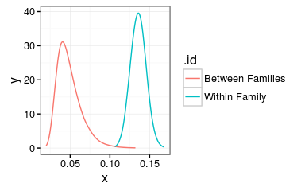

Posterior variances within and between families

Posterior modes and 95% HPD Credible Intervals are 0.04 (0.024, 0.08) for the variance *between families* and 0.136 (0.116, 0.155) for the variance *within families*

## 4.2 Variance components

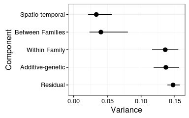

Posterior modes and 95% HPD Credible Intervals of the variance components.

Posterior modes and 95% HPD Credible Intervals are 0.147 (0.139, 0.157) for the *residual variance* and 0.137 (0.119, 0.156) for the *Additive-genetic variance*.

|  | Within Family | Between Families | Residual | Additive-genetic | Spatio-temporal |
| --- | --- | --- | --- | --- | --- |
| mode | 0.136 | 0.040 | 0.147 | 0.137 | 0.034 |
| lo | 0.116 | 0.024 | 0.139 | 0.119 | 0.022 |
| hi | 0.155 | 0.080 | 0.157 | 0.156 | 0.057 |

## 4.3 Effect of the Year

The following figure shows the mean posterior effect of the years, with 95% credible intervals for a reference value of BF of 3. Transformed scale.

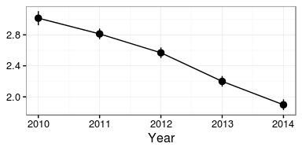

Posterior mean effect of the Year and 95% Credible Intervals. Transformed scale.

## 4.4 Effect of the Budflush

The following figure shows the mean posterior effect of the Budflush, with 95% credible intervals, in the latent scale.

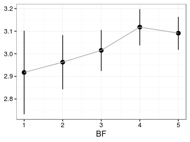

Posterior mean effect of the Budflush and 95% Credible Intervals for Year 2010. Transformed scale.

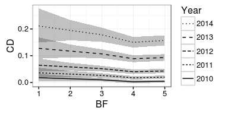

Posterior mean effect of the Budflush and 95% Credible Intervals, for each year. Original scale.

The following table gives the mean predicted CD by Year and BF.

mean predicted CD by Year and BF.

|  | 1 | 2 | 3 | 4 | 5 | mean |
| --- | --- | --- | --- | --- | --- | --- |
| 2010 | 0.018 | 0.014 | 0.010 | 0.003 | 0.005 | 0.010 |
| 2011 | 0.036 | 0.031 | 0.027 | 0.018 | 0.020 | 0.026 |
| 2012 | 0.065 | 0.058 | 0.052 | 0.040 | 0.043 | 0.052 |
| 2013 | 0.128 | 0.117 | 0.107 | 0.089 | 0.093 | 0.107 |
| 2014 | 0.211 | 0.195 | 0.178 | 0.150 | 0.157 | 0.178 |
| mean | 0.091 | 0.083 | 0.075 | 0.060 | 0.064 | 0.075 |

## 4.5 Heritability

We get the posterior additive variance from the model with **implicit** family effect. In order to compute the posterior density of the heritability, we sample from the joint posterior distribution of the hyperparameters of the model, and build a posterior sample of heritabilities with the formula
$$h^2 = \frac{\sigma^2_a}{\sigma^2_a + \sigma^2}$$

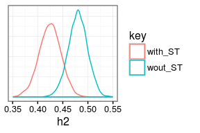

Posterior heritability

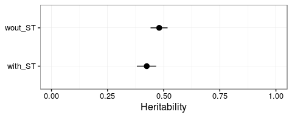

|  | mean | 2.5% | 97.5% |
| --- | --- | --- | --- |
| with_ST | 0.42 | 0.38 | 0.47 |
| wout_ST | 0.48 | 0.44 | 0.52 |

## 4.6 Fitted vs. Observations

Note that the fact that the prediction is not *centered* around the observed values is a consequence of the discrete nature of the response variable. It would be unlikely to predict a value under 1 or above 3.16, when these are the extreme observed values.

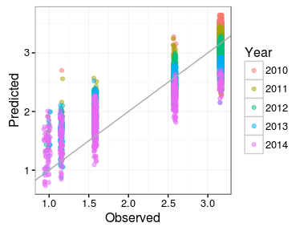

Fitted vs. observed values.Transformed scale.

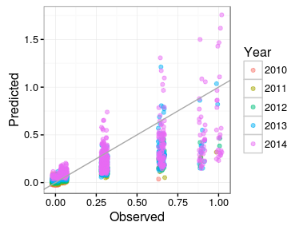

Fitted vs. observed values. Original scale.

## 4.7 Family effects

There are no extreme differences between families, but rather a continuous range of effects. However, most families have significant effects, and differences between the most extreme families are remarkable.

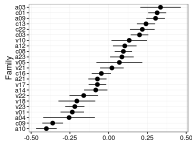

Posterior family effects

Note: not sure about this last interpretation.

## 4.8 Genetic effects

Here we plot the posterior distribution for the individual breeding values. Family effect included implicitly.

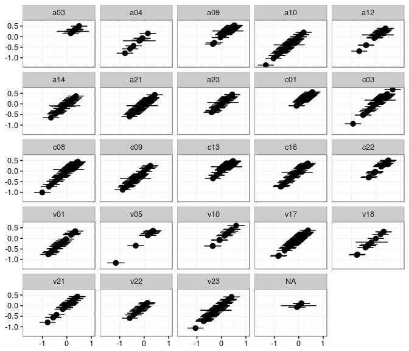

Posterior mean and 95% HPD Credible Interval of individual additive-genetic effects

## 4.9 Posterior distributions of spatial field’s characteristics

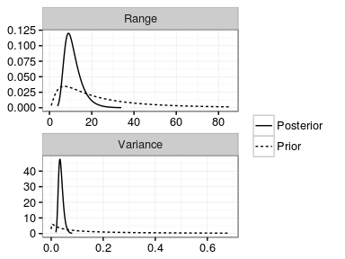

Posterior hyperparameters of the spatio-temporal field

## 4.10 Posterior spatiotemporal field

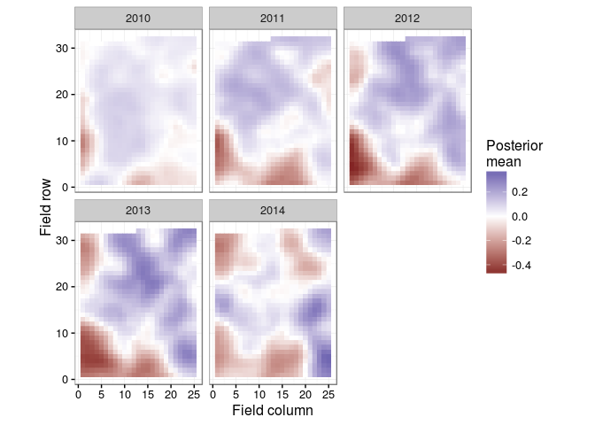

Posterior mean of the spatio-temporal field. Transformed scale.

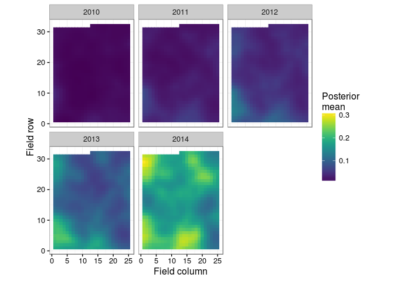

Posterior mean of the spatio-temporal field. Original scale, for a fixed BF value of 3.

## 4.11 Model diagnostics

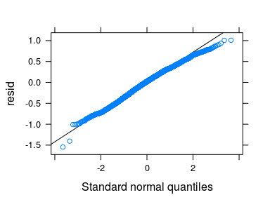

```
    Shapiro-Wilk normality test

data:  resid
W = 0.99423, p-value = 3.434e-11
```

The problem with the residuals persists. Although it does not seem that bad: the test statistic is very close to 1, and the qqplot looks fine except perhaps the most extreme couple of observations. The low p-value can be a consequence of the many observations (N=3840), and of the Gaussian approximation to the discrete outcome. I think the results are reliable anyways.

# 5 Conclusions

We fitted three main models, starting from a basic model from (Pliūra et al. 2011) as a reference, and pregresively adding more complexity. The replacement of the Family effect by the additive genetic effect at individual level produces a great improvement in the model according to all criteria. Furthermore, the replacement of the Blocks effect by the continuous spatio-temporal effect produces an additional significant improvement.

| Model | Description | Linear.predictor | DIC | p_D | WAIC | p_W | X.2log.lik |
| --- | --- | --- | --- | --- | --- | --- | --- |
| M1 | Pliūra et al. 2011 | Year + Block + *Fam* + *Fam:Block* | 5768 | 132 | 5766 | 126 | 6113 |
| M2 | Individual genetic effect | Year + Block + *BV* | 4548 | 619 | 4573 | 568 | 5588 |
| M3 | Spatio-temporal effect | Year + *ST* + *BV* | 4277 | 739 | 4307 | 666 | 5286 |
| M4 | Fixed provenance effect | Year + Prov + *ST* + *BV* | 4278 | 732 | 4310 | 661 | 5314 |
| M5 | Fixed Budflush effect | Year + BF + *ST* + *BV* | 4272 | 745 | 4304 | 671 | 5325 |
| M5.1 | explicit family effect | Year + BF + *ST* + *Fam* + *BV* | 4270 | 737 | 4305 | 667 | 5383 |
| M5.2 | null variance between families | Year + BF + *ST* + (*Fam*=0) + *BV* | 3858 | 1706 | 3851 | 1326 | 5633 |

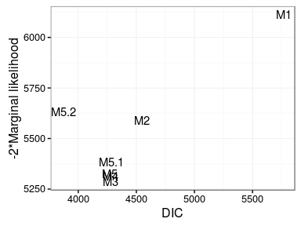

Model selection criteria.

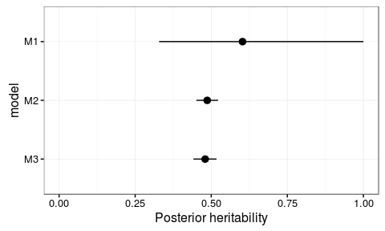

Posterior mean and 95% credible interval of heritability by model. Excluding ST variance.

Furthermore, slight variations around the latter to gather some additional results on the relevance of certain effects.

Specifically, the model $M3.1$ includes an **explicit** Family effect, to separate the *inter-family* genetic variance from the *intra-family* genetic variance. The posterior variance between families is only slightly higher to that of the reference model, while the posterior means of the family effects are very similar except some particular cases (notably, family **a04**).

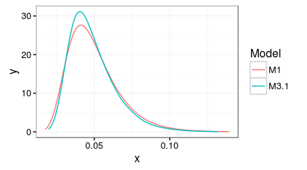

Posterior variance between families.

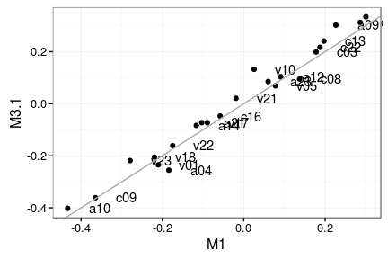

Posterior family effects by model.

Finally, we checked the irrelevance of the Provenance again by fitting the model $M3.3$ with the fixed effects of the provenances. While we see that the DIC is practically the same, the model including Provenances is somewhat more unlikely.

# References

Pliūra, Alfas, Vaidotas Lygis, Vytautas Suchockas, and Edmundas Bartkevičius. 2011. “Performance of Twenty Four European Fraxinus Excelsior Populations in Three Lithuanian Progeny Trials with a Special Emphasis on Resistance to Chlara Fraxinea.” *Baltic Forestry* 17 (1): 17–34.

Plummer, Martyn. 2008. “Penalized Loss Functions for Bayesian Model Comparison.” *Biostatistics* 9 (3). Oxford, England: 523–39. doi:10.1093/biostatistics/kxm049.

Visscher, Peter M., William G. Hill, and Naomi R. Wray. 2008. “Heritability in the Genomics Era – Concepts and Misconceptions.” *Nature Reviews Genetics* 9 (4). Nature Publishing Group: 255–66. doi:10.1038/nrg2322.